**Даренский Павел, 932201**

# Визуализация многомерных данных с использованием специализированной визуализации

1. Alcohol: Содержание алкоголя (% об.)
2. Malic acid: Содержание яблочной кислоты (г/л) — влияет на кислотность, вкус и структуру вина.
3. Ash: Зольность — остаток после испарения жидкости (мг/100 мл), отражает минеральный состав.
4. Alcalinity of ash: Щёлочность золы — мера щёлочности (pH) минеральных компонентов.
5. Magnesium: Содержание магния (мг/л) — важный минерал, влияет на ферментацию.
6. Total phenols: Общее содержание фенолов — антиоксиданты, важны для вкуса, структуры и устойчивости вина к старению.
7. Flavanoids: Содержание флавоноидов — подгруппа фенолов, сильно влияет на вкус и цвет вина.
8. Nonflavanoid phenols: Нефлавоноидные фенолы — другая часть фенольных соединений.
9. Proanthocyanins: Проантоцианины — тип танинов, отвечают за терпкость и способность вина к выдержке.
10. Color intensity: Интенсивность цвета вина.
11. Hue: Оттенок (тон цвета) вина — отношение поглощения света при 420 и 520 нм (оптическая характеристика цвета).
12. OD280/OD315 of diluted wines: Оптическая плотность при 280/315 нм — показатель содержания фенолов и цвета.
13. Proline: Содержание пролина — аминокислота, связана с уровнем зрелости и ферментации винограда.

```python
# !pip install ChernoffFace
```

```python
# подключаем необходимые библиотеки
from sklearn.datasets import load_wine
import pandas as pd
from ChernoffFace import variables_rescale
from ChernoffFace import chernoff_face
import matplotlib.cm
import matplotlib.pyplot as plt
import warnings
import logging
import plotly.express as px
from pandas.plotting import radviz
```

```python
# Чтобы подавить предупреждения
warnings.filterwarnings("ignore")
logging.getLogger('matplotlib.axes._base').setLevel(logging.ERROR)
```

```python
# Загружаем датасет о винах
wine = load_wine()
dfData = pd.DataFrame(data=wine.data, columns=wine.feature_names)
```

```python
dfData.head()
```

|  | alcohol | malic_acid | ash | alcalinity_of_ash | magnesium | total_phenols | flavanoids | nonflavanoid_phenols | proanthocyanins | color_intensity | hue | od280/od315_of_diluted_wines | proline |
| --- | --- | --- | --- | --- | --- | --- | --- | --- | --- | --- | --- | --- | --- |
| 0 | 14.23 | 1.71 | 2.43 | 15.6 | 127.0 | 2.80 | 3.06 | 0.28 | 2.29 | 5.64 | 1.04 | 3.92 | 1065.0 |
| 1 | 13.20 | 1.78 | 2.14 | 11.2 | 100.0 | 2.65 | 2.76 | 0.26 | 1.28 | 4.38 | 1.05 | 3.40 | 1050.0 |
| 2 | 13.16 | 2.36 | 2.67 | 18.6 | 101.0 | 2.80 | 3.24 | 0.30 | 2.81 | 5.68 | 1.03 | 3.17 | 1185.0 |
| 3 | 14.37 | 1.95 | 2.50 | 16.8 | 113.0 | 3.85 | 3.49 | 0.24 | 2.18 | 7.80 | 0.86 | 3.45 | 1480.0 |
| 4 | 13.24 | 2.59 | 2.87 | 21.0 | 118.0 | 2.80 | 2.69 | 0.39 | 1.82 | 4.32 | 1.04 | 2.93 | 735.0 |

```python
# Масштабируем данные
dfData2 = variables_rescale(dfData)
dfData2.head(5)
```

|  | alcohol | malic_acid | ash | alcalinity_of_ash | magnesium | total_phenols | flavanoids | nonflavanoid_phenols | proanthocyanins | color_intensity | hue | od280/od315_of_diluted_wines | proline |
| --- | --- | --- | --- | --- | --- | --- | --- | --- | --- | --- | --- | --- | --- |
| 0 | 0.842105 | 0.191700 | 0.572193 | 0.257732 | 0.619565 | 0.627586 | 0.573840 | 0.283019 | 0.593060 | 0.372014 | 0.455285 | 0.970696 | 0.561341 |
| 1 | 0.571053 | 0.205534 | 0.417112 | 0.030928 | 0.326087 | 0.575862 | 0.510549 | 0.245283 | 0.274448 | 0.264505 | 0.463415 | 0.780220 | 0.550642 |
| 2 | 0.560526 | 0.320158 | 0.700535 | 0.412371 | 0.336957 | 0.627586 | 0.611814 | 0.320755 | 0.757098 | 0.375427 | 0.447154 | 0.695971 | 0.646933 |
| 3 | 0.878947 | 0.239130 | 0.609626 | 0.319588 | 0.467391 | 0.989655 | 0.664557 | 0.207547 | 0.558360 | 0.556314 | 0.308943 | 0.798535 | 0.857347 |
| 4 | 0.581579 | 0.365613 | 0.807487 | 0.536082 | 0.521739 | 0.627586 | 0.495781 | 0.490566 | 0.444795 | 0.259386 | 0.455285 | 0.608059 | 0.325963 |

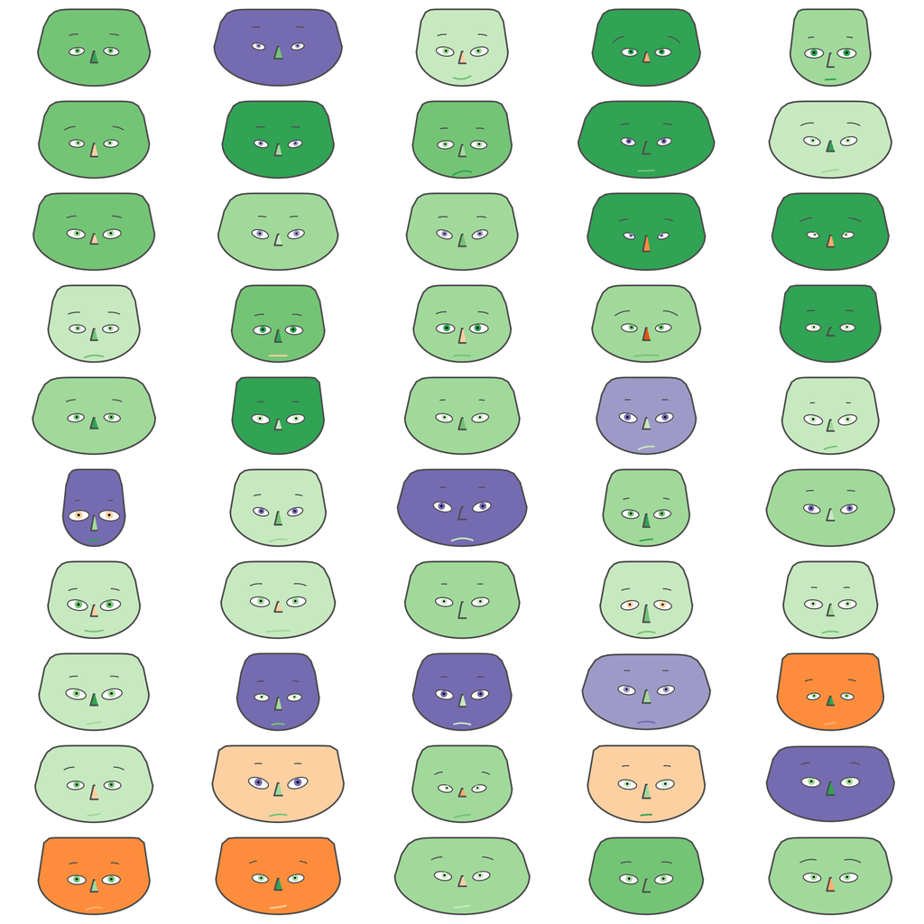

```python
# Покажем с помощью "Лиц Чернова" 50 образцов
dfData2 = dfData2.iloc[:50]

fig = chernoff_face(data=dfData2,
                    n_columns=5,
                    long_face=False,
                    color_mapper=matplotlib.cm.tab20c_r,
                    figsize=(12, 12), dpi=200)
fig.tight_layout()
matplotlib.pyplot.show()
```

Из полученых графических результатов, видно как по некоторым чертам лица образцы датасета близки, а по каким то различаются, бывает даже сильно. К примеру у кого то изгиб рта вниз - улыбка, у кого то вверх - грусть, у каких то лиц вообще отсутствует рот. Также в глаза бросается различие в форме лица - вытянутость по горизонтали или вертикали. Таким образом, уникальные образцы разглядеть трудно, сгруппировать по каким-то чертам визуально можно.

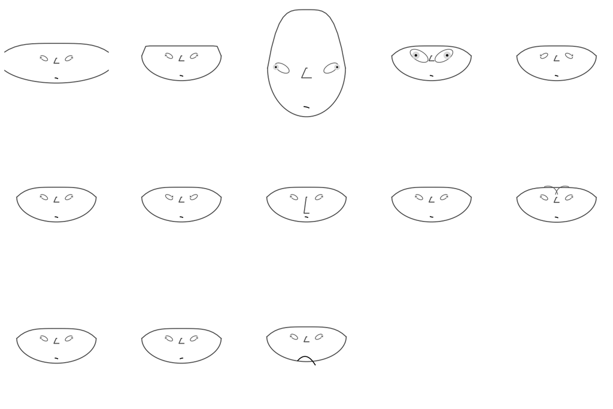

```python
# Попробуем отобразить по одному лицу на признак, и визуально определить какая черта лица отвечает за какой признак датафрейма нашего
import numpy as np
test_data = np.eye(len(wine.feature_names))
test_df = pd.DataFrame(test_data, columns=wine.feature_names)
test_df = variables_rescale(test_df)

fig = chernoff_face(data=test_df, n_columns=5, figsize=(18, 12))
plt.show()
```

Как видно вероятнее всего за наличие алкоголя в вине отвечает ширина лица, за количество вещества "пролина" в вине отвечает размер рта, и т.д.

Все признаки "Лица Чернова" из Википедии:

1. Размер глаза
2. Размер зрачка
3. Позиция зрачка
4. Наклон глаза
5. Горизонтальная позиция глаза
6. Вертикальная позиция глаза
7. Изгиб брови
8. Плотность брови
9. Горизонтальная позиция брови
10. Вертикальная позиция брови
11. Верхняя граница волос
12. Нижняя граница волос
13. Обвод лица
14. Темнота волос
15. Наклон штриховки волос
16. Нос
17. Размер рта
18. Изгиб рта

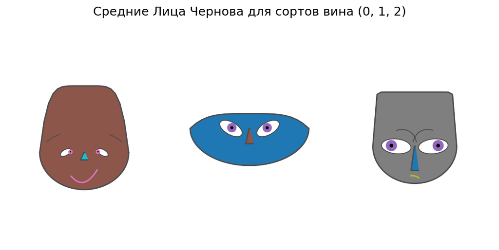

```python
dfData['target'] = wine.target  # добавим метку сорта

# Группируем и берём средние значения по признакам
grouped_df = dfData.groupby('target').mean()

# Масштабируем средние значения
scaled_df = variables_rescale(grouped_df)

# Строим Лица Чернова для 3 средних лиц (по каждому сорту)
fig = chernoff_face(
    data=scaled_df,
    n_columns=3,
    long_face=False,
    color_mapper=matplotlib.cm.tab10,
    figsize=(8, 4),
    dpi=150
)
fig.suptitle("Средние Лица Чернова для сортов вина (0, 1, 2)", fontsize=14)
fig.tight_layout()
plt.show()
```

Добавив метку класса из датасета, получим разделение по сортам. Отобразив тем же методом (Лица Чернова), видно как сильно лица отличаются - сорта. К примеру по количеству алкоголя в среднем сорт_0 и сорт_2 скорее всего близки, в отличие от сорта_1. Зато количество пролина в вине у сорта_0 больше всего - видно отчетливо. Также в глаза бросаются такие черты лица как - зрачки их размер и положение. Из выводов выше, о том какой признак лица отвечает за какой признак в дата фрейме, можно сделать предположение что в среднем мера щёлочности (pH) минеральных компонентов у сорта_0 сильно отличается от двух других сортов (ниже увидим численно как) - размер зрачков, а содержание флавоноидов у сорта_0 также отличается от других сортов (ниже увидим численно как) - положение зрачков по x.

```python
grouped_df.head()
```

| target | alcohol | malic_acid | ash | alcalinity_of_ash | magnesium | total_phenols | flavanoids | nonflavanoid_phenols | proanthocyanins | color_intensity | hue | od280/od315_of_diluted_wines | proline |
| --- | --- | --- | --- | --- | --- | --- | --- | --- | --- | --- | --- | --- | --- |
| 0 | 13.744746 | 2.010678 | 2.455593 | 17.037288 | 106.338983 | 2.840169 | 2.982373 | 0.290000 | 1.899322 | 5.528305 | 1.062034 | 3.157797 | 1115.711864 |
| 1 | 12.278732 | 1.932676 | 2.244789 | 20.238028 | 94.549296 | 2.258873 | 2.080845 | 0.363662 | 1.630282 | 3.086620 | 1.056282 | 2.785352 | 519.507042 |
| 2 | 13.153750 | 3.333750 | 2.437083 | 21.416667 | 99.312500 | 1.678750 | 0.781458 | 0.447500 | 1.153542 | 7.396250 | 0.682708 | 1.683542 | 629.895833 |

```python
# Выводим имена сортов для меток 0, 1 и 2
target_names = wine.target_names

# Печатаем имена для сортов 0, 1 и 2
print(f"Сорт 0: {target_names[0]}")
print(f"Сорт 1: {target_names[1]}")
print(f"Сорт 2: {target_names[2]}")
```

```
Сорт 0: class_0
Сорт 1: class_1
Сорт 2: class_2
```

```python
# Посмотрим 5 случайно выбранных образцов из нашего датафрейма
dfData.sample(5)
```

|  | alcohol | malic_acid | ash | alcalinity_of_ash | magnesium | total_phenols | flavanoids | nonflavanoid_phenols | proanthocyanins | color_intensity | hue | od280/od315_of_diluted_wines | proline | target |
| --- | --- | --- | --- | --- | --- | --- | --- | --- | --- | --- | --- | --- | --- | --- |
| 72 | 13.49 | 1.66 | 2.24 | 24.0 | 87.0 | 1.88 | 1.84 | 0.27 | 1.03 | 3.74 | 0.98 | 2.78 | 472.0 | 1 |
| 20 | 14.06 | 1.63 | 2.28 | 16.0 | 126.0 | 3.00 | 3.17 | 0.24 | 2.10 | 5.65 | 1.09 | 3.71 | 780.0 | 0 |
| 136 | 12.25 | 4.72 | 2.54 | 21.0 | 89.0 | 1.38 | 0.47 | 0.53 | 0.80 | 3.85 | 0.75 | 1.27 | 720.0 | 2 |
| 165 | 13.73 | 4.36 | 2.26 | 22.5 | 88.0 | 1.28 | 0.47 | 0.52 | 1.15 | 6.62 | 0.78 | 1.75 | 520.0 | 2 |
| 91 | 12.00 | 1.51 | 2.42 | 22.0 | 86.0 | 1.45 | 1.25 | 0.50 | 1.63 | 3.60 | 1.05 | 2.65 | 450.0 | 1 |

```python
# посмотрим информацию о признаках нашего датафрейма
dfData.info()
```

```
<class 'pandas.core.frame.DataFrame'>
RangeIndex: 178 entries, 0 to 177
Data columns (total 14 columns):
 #   Column                        Non-Null Count  Dtype
---  ------                        --------------  -----
 0   alcohol                       178 non-null    float64
 1   malic_acid                    178 non-null    float64
 2   ash                           178 non-null    float64
 3   alcalinity_of_ash             178 non-null    float64
 4   magnesium                     178 non-null    float64
 5   total_phenols                 178 non-null    float64
 6   flavanoids                    178 non-null    float64
 7   nonflavanoid_phenols          178 non-null    float64
 8   proanthocyanins               178 non-null    float64
 9   color_intensity               178 non-null    float64
 10  hue                           178 non-null    float64
 11  od280/od315_of_diluted_wines  178 non-null    float64
 12  proline                       178 non-null    float64
 13  target                        178 non-null    int64
dtypes: float64(13), int64(1)
memory usage: 19.6 KB
```

```python
# Загружаем винный датасет
wine = load_wine()
df = pd.DataFrame(wine.data, columns=wine.feature_names)
df["target"] = wine.target
df["target_name"] = df["target"].map(dict(enumerate(wine.target_names)))  # читаемые названия сортов
```

```python
fig = px.parallel_coordinates(
    df,
    color="target",
    labels={col: col.replace("_", " ").capitalize() for col in df.columns},
    dimensions=wine.feature_names,  # только признаки, без меток
    color_continuous_scale=px.colors.diverging.Tealrose,
    color_continuous_midpoint=1  # средний класс (0, 1, 2)
)
# Обновляем layout
fig.update_layout(
    title="Параллельные координаты: все образцы вина",
    title_x=0.5,  # Центрируем титул
    title_font=dict(size=20),  # Устанавливаем размер шрифта титула
    width=1400,  # Устанавливаем ширину графика
    height=1000,  # Устанавливаем высоту графика
)
fig.show()
```

[interactive chart not shown]

```python
# Группируем по классу, берём средние значения
df_grouped = df.groupby("target_name").mean().reset_index()

fig = px.parallel_coordinates(
    df_grouped,
    color="target",
    labels={col: col.replace("_", " ").capitalize() for col in df_grouped.columns},
    dimensions=wine.feature_names,
    color_continuous_scale=px.colors.diverging.Tealrose,
    color_continuous_midpoint=1
)
fig.update_layout(title="Параллельные координаты: средние значения по сортам вина", title_x=0.5)
fig.show()
```

[interactive chart not shown]

Здесь в среднем видно как вышеперечисленные выводы либо принимаются, либо далеки от подтверждения.

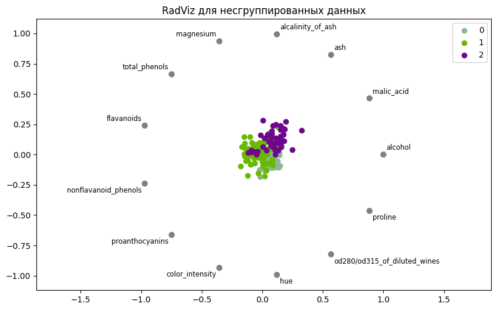

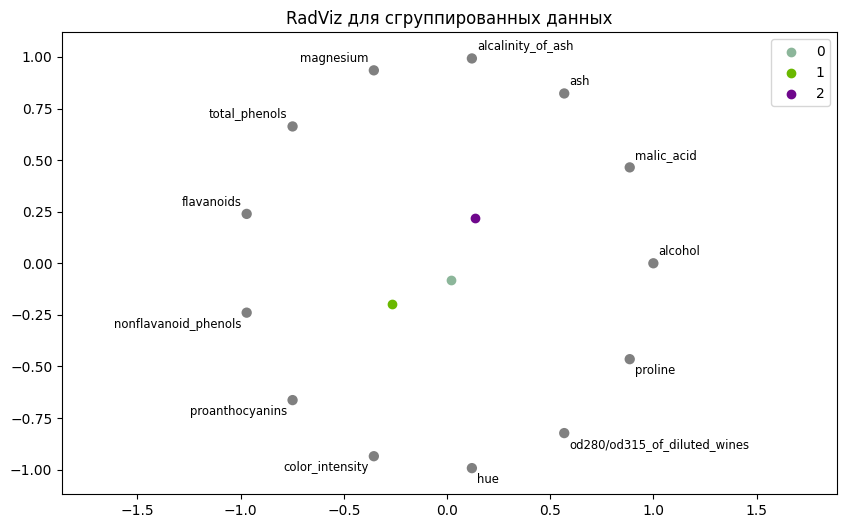

```python
# Подключаем необходимые библиотеки
import pandas as pd
import matplotlib.pyplot as plt
from sklearn.datasets import load_wine
from pandas.plotting import radviz

# Загружаем датасет о винах
wine = load_wine()
dfData = pd.DataFrame(data=wine.data, columns=wine.feature_names)

# Добавим метку сорта
dfData['target'] = wine.target

# Масштабируем данные (не забываем сохранить 'target' в dfData)
from sklearn.preprocessing import StandardScaler
scaler = StandardScaler()
scaled_df = dfData.copy()  # Сделаем копию, чтобы не потерять оригинальные данные
scaled_df[scaled_df.columns[:-1]] = scaler.fit_transform(scaled_df[scaled_df.columns[:-1]])

# Несгруппированные данные: визуализация RadViz
plt.figure(figsize=(10, 6))
radviz(scaled_df, 'target')
plt.title('RadViz для несгруппированных данных')
plt.show()

# Группируем данные по метке сорта
grouped_df = dfData.groupby('target').mean()
grouped_df['target'] = grouped_df.index  # Добавляем колонку 'target' обратно для визуализации

# Сгруппированные данные: визуализация RadViz
plt.figure(figsize=(10, 6))
radviz(grouped_df, 'target')
plt.title('RadViz для сгруппированных данных')
plt.show()
```

Данный тип графика радиальных координат имеет вид многогранника, в котором каждый признак связан с вершиной, а объекты (винные сорта) отображаются внутри этого многогранника. В несгруппированных образцах видно как они всё равно формируются в кучи - что говорит о том что они имеют схожести по некоторым признакам, что позволило бы их использовать в качестве переменных предсказательной модели, если такая задача стоит перед нами. Для сгруппированных данных видно по каким признакам в особенности сорта отличаются, к примеру сорт_0 ближе к вершине proline что говорит о том что по этому признаку он имеет более высокое значение (выше мы видели что это так).

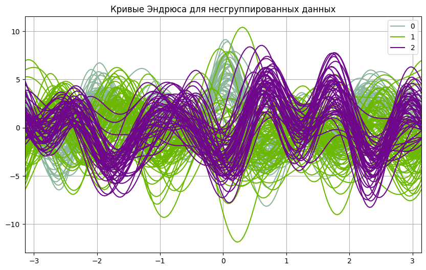

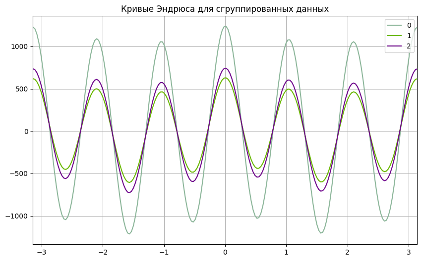

```python
# Подключаем необходимые библиотеки
import pandas as pd
import matplotlib.pyplot as plt
from sklearn.datasets import load_wine
from pandas.plotting import andrews_curves

# Загружаем датасет о винах
wine = load_wine()
dfData = pd.DataFrame(data=wine.data, columns=wine.feature_names)

# Добавим метку сорта
dfData['target'] = wine.target

# Масштабируем данные
from sklearn.preprocessing import StandardScaler
scaler = StandardScaler()
scaled_df = dfData.copy()  # Сделаем копию, чтобы не потерять оригинальные данные
scaled_df[scaled_df.columns[:-1]] = scaler.fit_transform(scaled_df[scaled_df.columns[:-1]])

# Несгруппированные данные: визуализация кривых Эндрюса
plt.figure(figsize=(10, 6))
andrews_curves(scaled_df, 'target')
plt.title('Кривые Эндрюса для несгруппированных данных')
plt.show()

# Группируем данные по метке сорта
grouped_df = dfData.groupby('target').mean()
grouped_df['target'] = grouped_df.index  # Добавляем колонку 'target' обратно для визуализации

# Сгруппированные данные: визуализация кривых Эндрюса
plt.figure(figsize=(10, 6))
andrews_curves(grouped_df, 'target')
plt.title('Кривые Эндрюса для сгруппированных данных')
plt.show()
```

Этот метод визуализации многомерных данных, который позволяет представить многомерные объекты в виде кривых в двумерном пространстве. Каждая кривая представляет один объект, и ее форму определяют значения признаков для этого объекта. Этот метод полезен для визуализации структуры данных, а также для обнаружения закономерностей и кластеров.

Визуально это полезно для понимания того, какие сорта имеют схожие или отличительные признаки. Видно как в среднем сорт_1 и сорт_2 достаточно отличаются от сорта_0, что выше можно заметить по численным выводам. Что говорит об уникальности сорта_0 по многим признакам, а сорт_1 и сорт_2 труднее отличать между собой из-за близости.